# EDA ⯈ Categorical Data Worksheet

Jill E. Thomley

Last rendered on Wednesday, January 19, 2022 @ 03:38 PM

## Packages Used

```r
library(tidyverse)
library(waffle)
```

## DataSets Used

### Popular Kids Study

You can read more about this dataset on its [description page](https://stat-jet-asu.github.io/Datasets/InstructorDescriptions/popular.html).

```r
kids <- read_csv("https://raw.githubusercontent.com/STAT-JET-ASU/Datasets/master/Instructor/popular.csv")
glimpse(kids)
```

```
Rows: 478
Columns: 9
$ gender        <chr> "boy", "boy", "girl", "girl", "girl", "girl", "girl", "g…
$ grade         <dbl> 5, 5, 5, 5, 5, 5, 5, 5, 5, 5, 5, 4, 4, 4, 4, 4, 4, 4, 4,…
$ age           <dbl> 11, 10, 11, 11, 10, 11, 10, 10, 10, 10, 11, 10, 9, 9, 9,…
$ district_type <chr> "rural", "rural", "rural", "rural", "rural", "rural", "r…
$ top_goal      <chr> "sports", "popular", "popular", "popular", "popular", "p…
$ grades_rank   <dbl> 1, 2, 4, 2, 4, 4, 3, 3, 3, 4, 2, 2, 2, 4, 4, 1, 3, 3, 2,…
$ sports_rank   <dbl> 2, 1, 3, 3, 2, 2, 4, 4, 2, 3, 3, 3, 3, 2, 3, 3, 1, 4, 3,…
$ looks_rank    <dbl> 4, 4, 1, 4, 1, 1, 1, 2, 1, 2, 1, 4, 4, 3, 2, 2, 2, 1, 1,…
$ money_rank    <dbl> 3, 3, 2, 1, 3, 3, 2, 1, 4, 1, 4, 1, 1, 1, 1, 4, 4, 2, 4,…
```

### STT3850 Students

This dataset contains information about students in Dr. Thomley’s past STT3850 classes.

```r
students <- read_csv("https://raw.githubusercontent.com/STAT-JET-ASU/Datasets/master/Instructor/stt3850majors.csv")
glimpse(students)
```

```
Rows: 706
Columns: 6
$ College     <chr> "AS", "AS", "AS", "AS", "AS", "AS", "AS", "AS", "AS", "AS"…
$ Year        <chr> "Junior", "Junior", "Senior", "Junior", "Senior", "Sophomo…
$ BannerMajor <chr> "Computer Science", "Mathematics, General Mathematics", "C…
$ CodedMajor  <chr> "Computer Science", "Mathematical Sciences", "Computer Sci…
$ Semester    <chr> "F14", "F14", "F14", "F14", "F14", "F14", "F14", "F14", "F…
$ AY          <chr> "2014-2015", "2014-2015", "2014-2015", "2014-2015", "2014-…
```

## Tabulating Data

### Frequency

I want to take the kids dataset *and then* count how many kids are in each grade. The pipe can be read as *and then* in this process. The counts produced by the `count()` function go into a column labeled `n`. The output of this process is another dataset (tibble). This is good, because we can use other dplyr verbs to manipulate this output.

```r
kids %>%
  count(grade)
```

```
# A tibble: 3 × 2
  grade     n
  <dbl> <int>
1     4   119
2     5   176
3     6   183
```

### Relative Frequency

The way we add a new column or variable to a dataset is with the `mutate()` function. I mathematically manipulate the `n` column into the `rel_freq` column using the function `prop.table()`.

```r
kids %>%
  count(grade) %>%
  mutate(rel_freq = prop.table(n))
```

```
# A tibble: 3 × 3
  grade     n rel_freq
  <dbl> <int>    <dbl>
1     4   119    0.249
2     5   176    0.368
3     6   183    0.383
```

### Cumulative Frequency

Using `mutate()` and the cumulative sum function `cumsum()`, I can manipulate the `n` and `rel_freq` columns to add cumulative frequency and cumulative relative frequency columns.

```r
kids %>%
  count(grade) %>%
  mutate(
    cum_freq = cumsum(n),
    rel_freq = prop.table(n),
    cum_rel_freq = cumsum(rel_freq)
  )
```

```
# A tibble: 3 × 5
  grade     n cum_freq rel_freq cum_rel_freq
  <dbl> <int>    <int>    <dbl>        <dbl>
1     4   119      119    0.249        0.249
2     5   176      295    0.368        0.617
3     6   183      478    0.383        1
```

### New Example!

To plot a different variable from the same dataset, just change the variable name!

What are kids’ top goals?

```r
kids %>%
  count(top_goal) %>%
  mutate(rel_freq = prop.table(n))
```

```
# A tibble: 3 × 3
  top_goal     n rel_freq
  <chr>    <int>    <dbl>
1 grades     247    0.517
2 popular    141    0.295
3 sports      90    0.188
```

Where do kids rank grades in terms of contributing to popularity (1 = most important)?

```r
kids %>%
  count(grades_rank) %>%
  mutate(
    cum_freq = cumsum(n),
    rel_freq = prop.table(n),
    cum_rel_freq = cumsum(rel_freq)
  )
```

```
# A tibble: 4 × 5
  grades_rank     n cum_freq rel_freq cum_rel_freq
        <dbl> <int>    <int>    <dbl>        <dbl>
1           1    94       94    0.197        0.197
2           2   123      217    0.257        0.454
3           3   133      350    0.278        0.732
4           4   128      478    0.268        1
```

## Plotting Data

### Barplot for One Variable

These are the same plot *geometry*, except the *aesthetic* (`aes`) variable is on the x axis in one plot and the y axis in the other. The `+` sign in ggplot works much like the `%>%`—it adds another layer to the plot.

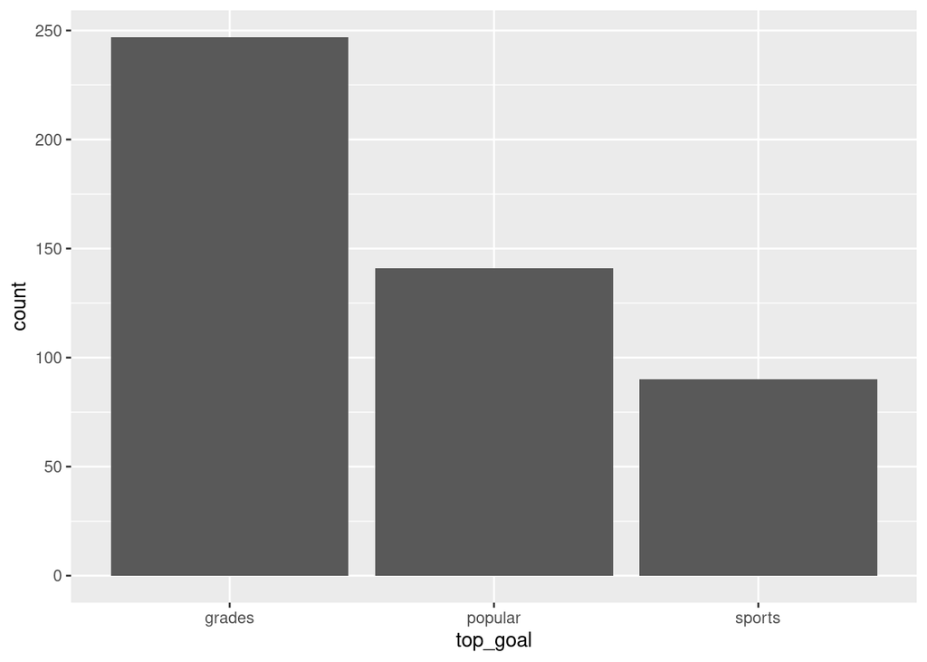

```r
ggplot(kids, aes(x = top_goal)) +
  geom_bar()
```

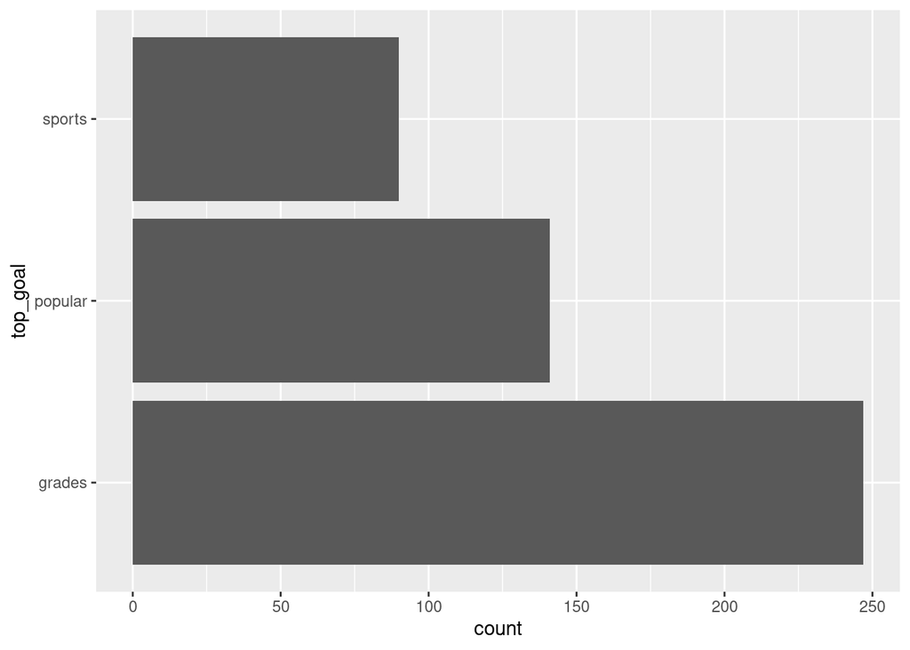

```r
ggplot(kids, aes(y = top_goal)) +
  geom_bar()
```